[GitHub](https://github.com/JuliaGeometry/DelaunayTriangulation.jl)[](https://github.com/JuliaGeometry/DelaunayTriangulation.jl/tree/main/docs/src/literate_tutorials/operations_segment_insertion.jl)

# Triangulation Operations

## Segment Insertion

This tutorial shows how we can add segments into a triangulation. First, load the packages we need:

```julia
using DelaunayTriangulation
using CairoMakie
```

Let us now define our initial triangulation.

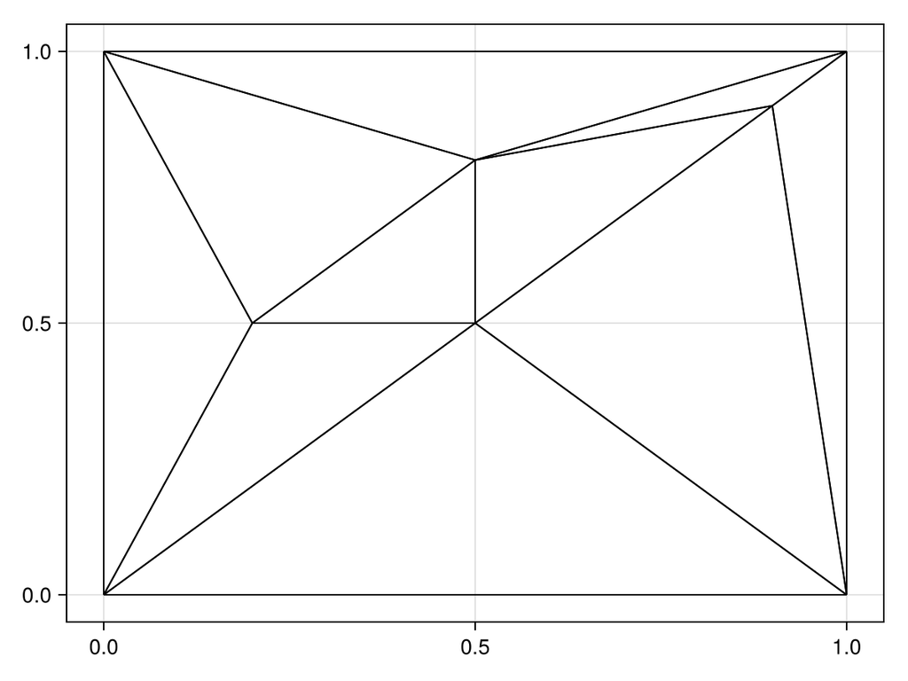

```julia
points = [(0.0, 0.0), (1.0, 0.0), (1.0, 1.0), (0.0, 1.0),
(0.9, 0.9), (0.5, 0.5), (0.2, 0.5), (0.5, 0.8)]
tri = triangulate(points)
fig, ax, sc = triplot(tri)
fig
```

To add a segment, we use `add_segment!`, providing the vertices for the points that a segment should be added between. Let us add a segment between `(0.0, 0.0)` and `(1.0, 1.0)`, which corresponds to vertices `1` and `3`.

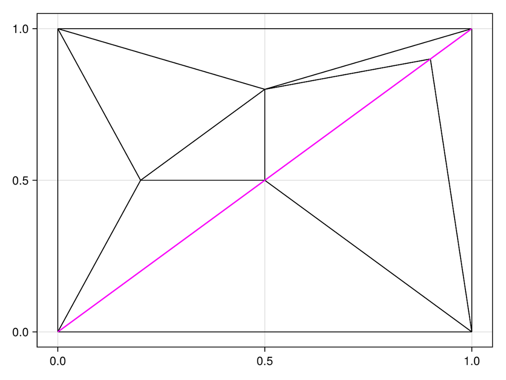

```julia
add_segment!(tri, 1, 3)
fig, ax, sc = triplot(tri, show_constrained_edges = true)
fig
```

Of course, this changed nothing since the segment was already there. We do note, though, that if we look at the constrained edges

```julia
get_interior_segments(tri)
```

```
Set{Tuple{Int64, Int64}} with 3 elements:
  (1, 6)
  (5, 3)
  (5, 6)
```

then we notice that the segment `(1, 3)` was converted into the segments `(1, 6)`, `(5, 3)`, and `(5, 6)`. This is because the segment `(1, 3)` crossed through other vertices, and so the algorithm automatically breaks down the segments into a sequence of connected collinear segments.

Now we add a segment that was not already there.

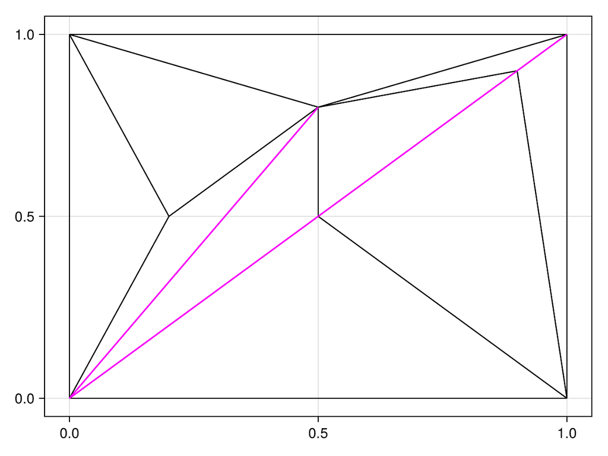

```julia
add_segment!(tri, 1, 8)
fig, ax, sc = triplot(tri, show_constrained_edges = true)
fig
```

Currently, the segments that you add must not intersect at an angle (they can be collinear with other edges as we have demonstrated above). To see what happens if we do this:

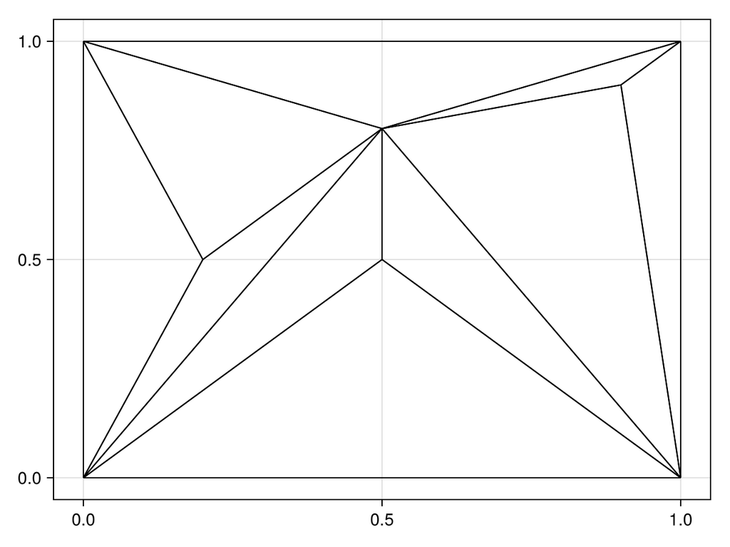

```julia
add_segment!(tri, 8, 2)
fig, ax, sc = triplot(tri)
fig
```

The other constrained edge was partially removed.

## Just the code

An uncommented version of this example is given below. You can view the source code for this file [here](https://github.com/JuliaGeometry/DelaunayTriangulation.jl/tree/main/docs/src/literate_tutorials/operations_segment_insertion.jl).

```julia
using DelaunayTriangulation
using CairoMakie

points = [(0.0, 0.0), (1.0, 0.0), (1.0, 1.0), (0.0, 1.0),
(0.9, 0.9), (0.5, 0.5), (0.2, 0.5), (0.5, 0.8)]
tri = triangulate(points)
fig, ax, sc = triplot(tri)
fig

add_segment!(tri, 1, 3)
fig, ax, sc = triplot(tri, show_constrained_edges = true)
fig

get_interior_segments(tri)

add_segment!(tri, 1, 8)
fig, ax, sc = triplot(tri, show_constrained_edges = true)
fig

add_segment!(tri, 8, 2)
fig, ax, sc = triplot(tri)
fig
```

*This page was generated using Literate.jl.*